# Relación de las actividades extracurriculares en el desarrollo personal de los estudiantes de la UTEC en el ciclo 2023-1

# 1 Introducción

## 1.1 Relevancia

**Motivación:**

La motivación en esta investiagcaión es la comprensión del valor de las actividades extracurriculares en el desarrollo personal de los estudiantes de la UTEC en el ciclo 2023-1. Nos planteamos preguntas fundamentales: ¿Cómo influyen estas actividades en el crecimiento integral de los estudiantes? ¿Cuál es la relación entre la participación en actividades extracurriculares y el rendimiento académico? ¿En qué medida estas actividades contribuyen al desarrollo de habilidades blandas? ¿La realción que presentan es negativa o positiva?

–

**Importancia:**

La importancia de este estudio radica en su relevancia social y laboral. En un mundo cada vez más competitivo, es fundamental que los estudiantes universitarios desarrollen tanto conocimientos teóricos como habilidades sociales como el liderazgo, el trabajo en equipo y la comunicación efectiva. Entender cómo las actividades extracurriculares pueden contribuir a estos aspectos permite establecer políticas educativas más sólidas y eficientes, preparando a los estudiantes de la UTEC para enfrentar los desafíos del mundo laboral y contribuir significativamente a la sociedad.

## 1.2 Objetivo

Para los siguientes objetivos, se planteo el objetivo principal de analizar la influencia de las actividades extracurriculares en el desarrollo personal de los estudiantes de la UTEC durante el ciclo 2023-1.

- **Objetivo 1:** Identificar los tipos de actividades extracurriculares más populares entre los estudiantes de la UTEC en el ciclo 2023-1.
- **Objetivo 2:** Analizar la relación entre la participación en actividades extracurriculares y el rendimiento académico de los estudiantes de la UTEC en el ciclo 2023-1.
- **Objetivo 3:** Analizar la relación de las actividades extracurriculares con el desarrollo de habilidades blandas de los estudiantes de la UTEC en el ciclo 2023-1.

## 1.3 Contexto

Para comprender adecuadamente el tema propuesto, es necesario tener en cuenta el siguiente conocimiento relacionado:

- **Actividades extracurriculares:** Se refiere a las actividades que se realizan externo al plan de estudios regular y tienen como objetivo complementar el aprendizaje y el desarrollo personal de los estudiantes. Esto puede incluir la participación en deportes, clubes, voluntariado, eventos culturales, trabajo, etc.
- **Desarrollo personal:** El desarrollo personal abarca el desarrollo y la mejora de las habilidades duras y blandas, conocimientos, actitudes y valores de una persona. Este desarrollo es esencial en la educación superior para enfrentar desafíos académicos y profesionales.

# 2 Datos

## 2.1 Recolección de datos

Para el proceso de recolección de datos plasmó una seria de preguntas en un formulario de Google, el cual fue distribuido virtual (mediante un link) y presencialmente (mediante código QR) a estudiantes de la UTEC.

Este metodo fue elegido debido a que la población de estudio son jóvenes, por ende, realizar las encuestas a través de redes sociales es la mejor manera de captar su atención y en caso de la presencialidad la gran parte de gente juven maneja fácilmente los códigos QR.

Debido al uso de google forms contamos con un archivo “csv” de los datos. Para leer el archivo tenemos que usar la libreria “readr”. Con la libreria ya instalada se puede leer el archivo “datos.csv”.

| Marca temporal | Dirección de correo electrónico | Edad: | Género: | Carrera: | Ciclo: | ¿Actualmente realizas alguna actividad extracurricular? | ¿En cuántas actividades extracurriculares participas actualmente? | ¿En que tipo de actividades extracurriculares participas actualmente? | ¿Cuáles son las actividades extracurriculares en las que participas actualmente? | ¿Cuántas horas a la semana inviertes en actividades extracurriculares? | ¿Qué tan satisfecho te sientes con tu participación en actividades extracurriculares? | ¿Cuántas horas a la semana inviertes en tus estudios (clases, tareas, estudiar)? | Orden de mérito en el ciclo 2022-2: | ¿Alguna vez has reprobado un curso? | ¿Crees que las actividades extracurriculares afectan en tu rendimiento académico? | ¿Cómo consideras que es tu nivel de desarrollo en habilidades blandas? | ¿Crees que las actividades extracurriculares afectan en tu desarrollo de habilidades blandas? | ¿Cuántas amistades/contactos consideras que has hecho participando en actividades extracurriculares? | Test de habilidades sociales | Test de liderazgo |
| --- | --- | --- | --- | --- | --- | --- | --- | --- | --- | --- | --- | --- | --- | --- | --- | --- | --- | --- | --- | --- |
| 26/04/2023 22:34:12 | roberto.vargas@utec.edu.pe | 19 | Masculino | Ingeniería Civil | 4 | Sí | 1 | Deportiva | Ajedrez, Fútbol | 4 | Muy satisfecho | 6 | Tercio superior | Sí | No afectan. | Regular | Si, afectan positivamente. | 5 | 8.75 | 8.38 |
| 26/04/2023 22:36:37 | marely.penadillo@utec.edu.pe | 18 | Femenino | Ingeniería Civil | 4 | No | 0 | Ninguna | Ninguna | 0 | Nada satisfecho | 30 | Medio superior | Sí | No afectan. | Regular | No afectan. | 0 | 5.75 | 5 |
| 26/04/2023 22:47:27 | sofia.poblete@utec.edu.pe | 18 | Femenino | Bioingeniería | 3 | Sí | 2 | Deportiva, Artística, Trabajo | Danza, Robótica | 4 | Medianamente satisfecho | 26 | Quinto superior | No | Si, afectan positivamente | Regular | No afectan. | 1 | 5 | 6.38 |
| 26/04/2023 22:56:43 | juan.hancco@utec.edu.pe | 21 | Masculino | Ingeniería Civil | 4 | No | 1 | Ninguna | Ninguna | 0 | Medianamente satisfecho | 50 | 10 primeros puestos | Sí | No afectan. | Regular | Si, afectan positivamente. | 4 | 6 | 6 |
| 26/04/2023 23:20:31 | stephanie.venegas@utec.edu.pe | 17 | Femenino | Bioingeniería | 3 | Sí | 1 | Académicas | Inglés | 6 | Muy satisfecho | 25 | Tercio superior | No | Si, afectan positivamente | Medianamente Alto | Si, afectan positivamente. | 2 | 6.25 | 6.88 |
| 27/04/2023 0:23:32 | adriano.delrosario@utec.edu.pe | 18 | Masculino | Ingeniería Mecánica | 3 | No | 0 | Ninguna | Ninguna | 0 | Nada satisfecho | 14 | Medio superior | Sí | No afectan. | Medianamente Bajo | No afectan. | 0 | 3.75 | 4.13 |
| 27/04/2023 0:31:12 | jairo.sanchez@utec.edu.pe | 17 | Masculino | Ingeniería Química | 3 | No | 0 | Ninguna | Fútbol | 0 | Medianamente satisfecho | 48 | Ninguno | Sí | Si, afectan positivamente | Regular | Si, afectan positivamente. | 0 | 5 | 5 |
| 27/04/2023 2:20:38 | diego.jauregui@utec.edu.pe | 22 | Masculino | Ingeniería Civil | 4 | Sí | 1 | Deportiva | Fútbol | 2 | Muy satisfecho | 77 | Ninguno | Sí | Si, afectan positivamente | Regular | Si, afectan positivamente. | 6 | 6.75 | 5.5 |
| 27/04/2023 15:34:02 | maria.quinte@utec.edu.pe | 19 | Femenino | Ingeniería Civil | 4 | Sí | 3 | Artística, Académicas | Danza, Inglés, Diseño o Marketing en organizaciones | 3 | Medianamente satisfecho | 10 | Tercio superior | Sí | No afectan. | Medianamente Alto | No afectan. | 15 | 7 | 5.88 |
| 27/04/2023 19:11:44 | matias.maravi@utec.edu.pe | 19 | Masculino | Ciencia de la Computación | 4 | Sí | 3 | Artística, Académicas, Voluntariado | Inglés, Miembro de una organización estudiantil | 5 | Muy satisfecho | 10 | Tercio superior | No | Si, afectan negativamente | Regular | Si, afectan positivamente. | 10 | 5.5 | 7.38 |

[output cut: 201 more lines]

## 2.2 Población, muestra y muestreo

**Población:**

Todos los estudiantes matriculados en el semestre 2023-1 en la universidad UTEC

**Muestra:**

Se determinó una muestra de 211 encuestados entre los estudiantes de la Universidad UTEC hasta el momento de envio del informe, superando el mínimo de 150 encuestados para lograr resultados sólidos y representativos, y considerando de la posibilidad de que existan observaciones no válidas y por lo tanto eliminadas.

**Muestreo:**

El muestreo utilizado es el “Muestreo aleatorio simple”, de modo que cada elemento de la población tiene la misma probabilidad de ser seleccionado para formar parte de la muestra.

## 2.3 Variables

| Variable | Descipción | Tipo | Restricción |
| --- | --- | --- | --- |
| Edad | Edad del encuestado | Cuantitativas Discretas | Número entero del 15 al 45. |
| Género | Género del encuestado | Cualitativa Nominal | Femenino, Masculino u Otro |
| Carrera | Carrera que estudia el encuestado | Cualitativa Nominal | Carrera que ofrece UTEC |
| Ciclo | Ciclo que esta cursando el encuestado | Cualitativa Ordinal | Número entero del 1 al 12 |
| Participación | Si el encuestado participa en alguna actividad extracurricular | Cualitativa Nominal | Sí o No |
| Cantidad | Cantidad de actividades extracurriculares en las que participa el encuestado | Cuantitativas Discretas | Número entero del 0 al 12 |
| Tipo | Tipo/s de actividad/es extracurricular/es en la que el encuestado participa | Cualitativa Nominal | Ninguna o Generalización de una actividad (Deportiva, Artística, etc.) |
| Actividades | Actividad/es extracurricular/es en la que el encuestado participa | Cualitativa Nominal | Ninguna o actividad extracurricular (Fútbol, Dibujo, etc.) |
| Horas Actividades | Horas invertidas a las actividades extracurriculares a la semana | Cuantitativas Discretas | Número entero del 0 al 80 |
| Satisfacción | Nivel de satisfacción del encuestado con su participación en actividades extracurriculares | Cualitativa Ordinal | Nada satisfecho, poco satisfecho, medianamente satisfecho, muy satisfecho o extremadamente satisfecho |
| Horas Estudios | Horas invertidas a la universidad (clases, tareas y estudiar) a la semana | Cuantitativas Discretas | Número entero del 5 al 100 |
| Orden de merito | Orden de mérito del ciclo 2022-2 del encuestado | Cualitativa Ordinal | 10 primeros puestos, Décimo/Quinto/Tercio/Medio superior o Ninguno |
| Reprobado | Si el encuestado ha reprobado algún curso durante sus estudios en UTEC | Cualitativa Nominal | Sí o No |
| Relacion rendimiento | Opinión sobre la relación entre las actividades y el rendimiento académico | Cualitativa Nominal | No afectan, Si afectan positivamente o Si afectan negativamente |
| Nivel habilidades | Nivel de desarrollo de habilidades blandas según la percepción del encuestado | Cualitativa Ordinal | Alto, Medianamente alto, Regular, Medianamente bajo o Bajo |
| Relacion habilidades | Opinión sobre la relación entre las actividades y las habilidades blandas | Cualitativa Nominal | No afectan, Si afectan positivamente o Si afectan negativamente |
| Amsitades | Cantidad de amistades hechas en actividades extracurriculares | Cuantitativas Discretas | Número entero del 0 al 100 |
| Test Social | Puntaje del test de habilidades sociales | Cuantitativas Continuas | Número del 0 al 10 |
| Test Liderazgo | Puntaje del test de liderazgo y trabajo en equipo | Cuantitativas Continuas | Número del 0 al 10 |

Cosas que corregir:

1. Eliminar variables no relevantes
2. Cambiar el nombre de las variables
3. Cambiar tipo de varaible incorrecta

```r
# Eliminar columna de fecha y correo
data<-raw[,3:21]

# Cambiar nombre de las variables

names(data)<-c("Edad","Genero","Carrera","Ciclo","Participacion","Cantidad","Tipo","Actividades","Horas_Actividades","Satisfaccion","Horas_Estudios","Orden_de_merito","Reprobado","Relación_rendimiento","Nivel_habilidades","Relacion_habilidades","Amistades","Test_Social","Test_Liderazgo")

# Cambiar tipo de variable

data$Ciclo<-as.character(data$Ciclo)
data$"Test_Social"<-as.numeric(data$"Test_Social")
data$"Test_Liderazgo"<-as.numeric(data$"Test_Liderazgo")
```

| Edad | Genero | Carrera | Ciclo | Participacion | Cantidad | Tipo | Actividades | Horas_Actividades | Satisfaccion | Horas_Estudios | Orden_de_merito | Reprobado | Relación_rendimiento | Nivel_habilidades | Relacion_habilidades | Amistades | Test_Social | Test_Liderazgo |
| --- | --- | --- | --- | --- | --- | --- | --- | --- | --- | --- | --- | --- | --- | --- | --- | --- | --- | --- |
| 19 | Masculino | Ingeniería Civil | 4 | Sí | 1 | Deportiva | Ajedrez, Fútbol | 4 | Muy satisfecho | 6 | Tercio superior | Sí | No afectan. | Regular | Si, afectan positivamente. | 5 | 8.75 | 8.38 |
| 18 | Femenino | Ingeniería Civil | 4 | No | 0 | Ninguna | Ninguna | 0 | Nada satisfecho | 30 | Medio superior | Sí | No afectan. | Regular | No afectan. | 0 | 5.75 | 5.00 |
| 18 | Femenino | Bioingeniería | 3 | Sí | 2 | Deportiva, Artística, Trabajo | Danza, Robótica | 4 | Medianamente satisfecho | 26 | Quinto superior | No | Si, afectan positivamente | Regular | No afectan. | 1 | 5.00 | 6.38 |
| 21 | Masculino | Ingeniería Civil | 4 | No | 1 | Ninguna | Ninguna | 0 | Medianamente satisfecho | 50 | 10 primeros puestos | Sí | No afectan. | Regular | Si, afectan positivamente. | 4 | 6.00 | 6.00 |
| 17 | Femenino | Bioingeniería | 3 | Sí | 1 | Académicas | Inglés | 6 | Muy satisfecho | 25 | Tercio superior | No | Si, afectan positivamente | Medianamente Alto | Si, afectan positivamente. | 2 | 6.25 | 6.88 |
| 18 | Masculino | Ingeniería Mecánica | 3 | No | 0 | Ninguna | Ninguna | 0 | Nada satisfecho | 14 | Medio superior | Sí | No afectan. | Medianamente Bajo | No afectan. | 0 | 3.75 | 4.13 |
| 17 | Masculino | Ingeniería Química | 3 | No | 0 | Ninguna | Fútbol | 0 | Medianamente satisfecho | 48 | Ninguno | Sí | Si, afectan positivamente | Regular | Si, afectan positivamente. | 0 | 5.00 | 5.00 |
| 22 | Masculino | Ingeniería Civil | 4 | Sí | 1 | Deportiva | Fútbol | 2 | Muy satisfecho | 77 | Ninguno | Sí | Si, afectan positivamente | Regular | Si, afectan positivamente. | 6 | 6.75 | 5.50 |
| 19 | Femenino | Ingeniería Civil | 4 | Sí | 3 | Artística, Académicas | Danza, Inglés, Diseño o Marketing en organizaciones | 3 | Medianamente satisfecho | 10 | Tercio superior | Sí | No afectan. | Medianamente Alto | No afectan. | 15 | 7.00 | 5.88 |
| 19 | Masculino | Ciencia de la Computación | 4 | Sí | 3 | Artística, Académicas, Voluntariado | Inglés, Miembro de una organización estudiantil | 5 | Muy satisfecho | 10 | Tercio superior | No | Si, afectan negativamente | Regular | Si, afectan positivamente. | 10 | 5.50 | 7.38 |

[output cut: 201 more lines]

## 2.4 Manejo de variables con opción múltiple

Las variables “Tipo” y “Actividades” fueron asignadas como de respuesta múltiple, por lo que las diferentes respuestas se separaraban con “,” [coma espacio].

El valor de esta variable está dado por un string, por lo que para facilitar el acceso a los subvalores se crearon las funciones separar (separa en vector) y coincidencia (busca coincidencia)

```r
separar<-function(vector){
  nuevo<-c()
  cont<-1
  for (i in 1:length(vector)){
    dato<-vector[i]
    subdato<-unlist(strsplit(dato,", "))
    for (j in 1:length(subdato)){
      nuevo[cont]<-subdato[j]
      cont<-cont+1
      }
  }

  return(nuevo)

  }

coincidencia<-function(vector,palabra){
  vector<-separar(vector)
  suma<-sum(vector==palabra)
  return(as.logical(suma))
}
```

Al dar la posibilidad de que el encuestado escribiera su propia respuesta ocurrieron errores como separación incorrecta de subvalores, especificación excesiva en actividad, faltas de ortografía, entre otros.

Para corregir estos errores se realizarón las siguientes medidas:

1. Corregir si las respuestas no estan separadas por “,” [coma espacio]
2. Simplificar las respuestas para agruparlas mediante filtros
3. Corregir otros errores

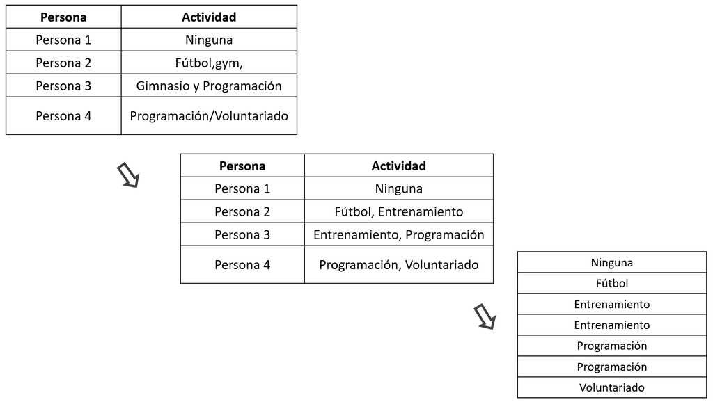

“Figura 1: Proceso de corrección y función separar”

```r
coma<-function(palabra){

    palabra<-unlist(strsplit(palabra,""))
    tam<-length(palabra)

    for (i in 1:tam){
      if (palabra[i]==","){
        if (i==tam){
          palabra[i]<-""
        }
        if (i!=tam & palabra[i+1]!=" "){
          palabra[i]<-paste(palabra[i]," ",sep="")
        }

      }

      else if (palabra[i]=="y" & i!=tam){
        if (palabra[i-1]==" " & palabra[i+1]==" "){
          palabra[i]<-","
          palabra[i-1]<-""
        }

      }

      else if (palabra[i]=="/"){
        palabra[i]<-", "
      }
    }

    palabran <- palabra[1]

    for (k in 2:tam){
      palabran<-paste(palabran,palabra[k],sep="")
    }
    return(palabran)
  }


filtros_1<-function(palabra){
    if (palabra=="Ninguno")
      palabra<-"Ninguna"
    else if (palabra=="Juegos" | palabra=="Robótica" | palabra=="Esports" | palabra =="videojuegos")
      palabra<-"Tecnológica"
    else if (palabra=="Gimnasio")
      palabra<-"Deportiva"
    return (palabra)
  }


filtros_2<-function(palabra){
    gsub(" ","",palabra)
    if (palabra=="Ninguno")
      palabra<-"Ninguna"
    else if (palabra=="Basquetball")
      palabra<-"Basquet"
    else if (palabra=="Esports" | palabra=="Robótica" | palabra=="Esports" | palabra =="videojuegos")
      palabra<-"Videojuegos"
    else if (palabra=="DiseñooMarketingenorganizaciones" | palabra=="Miembrodeunaorganizaciónestudiantil" | palabra=="Organizaciónuniversitaria" | palabra=="participandoenlasactividadesdeIEEE"| palabra=="Club"| palabra=="IEEERAS" )
      palabra<-"Organizaciones estudiantiles"
    else if (palabra=="Voluntariado(enseñar)" | palabra=="voluntariado"| palabra=="Volountariado")
      palabra<-"Voluntariado"
    else if (palabra=="karate")
      palabra<-"Artes Marciales"
    else if (palabra=="Bici")
      palabra<-"Ciclismo"
    else if (palabra=="Gym"| palabra=="gimnasio" | palabra=="Ejercicios" | palabra=="Calistenia"| palabra=="Gimnasio")
      palabra<-"Entrenamiento"
    else if (palabra=="EnseñandocursosSTEManiñosdehablainglesa" | palabra=="Mentoriasacadémicas"|palabra=="ProfesorparticulardeC20A")
      palabra<-"Enseñar"
    else if (palabra=="Ingles")
      palabra<-"Inglés"
    else if (palabra=="Mesero"| palabra=="emprendimiento" )
      palabra<-"Trabajo"
    else if (palabra=="ProgramaciónCompetitiva" | palabra=="CursodeProgramación")
      palabra<-"Programación"
    return (palabra)
  }

redefinir_1<-function(vector){
    nuevo<-vector

    for (i in 1:length(vector)){
      dato<-vector[i]
      dato<-coma(dato)

      subdato<-unlist(strsplit(dato,", "))
      for (j in 1:length(subdato)){
        subdato[j]<-filtros_1(subdato[j])
      }

      if (length(subdato)>1){
        subdato<-subdato[subdato!="Ninguna"]
      }

      dato<-subdato[1]
      if (length(subdato)>1){
        for (j in 2:length(subdato)){
          dato<-paste(dato,subdato[j],sep=", ")
        }
      }
      nuevo[i]<-dato


    }

    return (nuevo)
  }

redefinir_2<-function(vector){
    nuevo<-vector

    for (i in 1:length(vector)){
      dato<-vector[i]
      dato<-coma(dato)
      subdato<-unlist(strsplit(dato,", "))
      for (j in 1:length(subdato)){
        subdato[j]<-filtros_2(subdato[j])
      }

      if (length(subdato)>1){
        subdato<-subdato[subdato!="Ninguna"]
      }
      dato<-subdato[1]
      if (length(subdato)>1){
        for (j in 2:length(subdato)){
          dato<-paste(dato,subdato[j],sep=", ")
        }
      }
      nuevo[i]<-dato

    }

    return (nuevo)
  }




data$"Tipo"<-redefinir_1(data$"Tipo")
data$"Actividades"<-redefinir_2(data$"Actividades")
```

## 2.5 Limpieza de base de datos

En primer lugar se eliminará las observaciones que tengan variables sin valores (NA). Debido a un error que fue posteriormente corregido solo hay una observación que tiene algún valor vacio.

Se corregirán incongurencias obvias en las respuestas

1. En caso que únicamente la variable Participación (Sí/No) no coincida con el resto de respuestas.
2. Contadas correciones particulares que no figuran en el archivo csv dado por forms.

Finalmente se eliminarán observaciones que presentes errores como:

1. La variable Participación no coincida con alguna de las respuestas de las siguientes preguntas (Contradicción entre respuestas)
2. Ambos resultados de los tests sean igual a 0 (indica que posiblemente los test no se realizaron)

```r
DF<-data[rowSums(is.na(data))==0,]

DF$Participacion[DF$Cantidad>0 & DF$`Horas_Actividades`>0 & DF$Actividades!="Ninguna" & DF$Tipo!="Ninguna"]<-"Sí"
DF$Participacion[DF$Cantidad==0 & DF$`Horas_Actividades`==0 & DF$Actividades=="Ninguna" & DF$Tipo=="Ninguna"]<-"No"

DF$Actividades[158] <- "Proyecto Universitario"
DF$Actividades[148] <- "Idioma"



DF<-DF[!(DF$Participacion=="No" & DF$Cantidad>0),]
DF<-DF[!(DF$Participacion=="No" & DF$`Horas_Actividades`>0),]
DF<-DF[!(DF$Participacion=="No" & DF$Actividades!="Ninguna"),]
DF<-DF[!(DF$Participacion=="No" & DF$Tipo!="Ninguna"),]
DF<-DF[!(DF$Participacion=="Sí" & DF$Cantidad==0),]

DF<-DF[!(DF$"Test_Social"==0 & DF$"Test_Liderazgo"==0),]
DF<-DF[!(DF$"Test_Social">10 | DF$"Test_Liderazgo">10),]
```

**Tamaño de Data Frame Original**

```
## [1] "Variables: 21"
```

```
## [1] "Observaciones: 211"
```

**Tamaño de Data Frame despúes de corección de variables y limpieza de datos**

```
## [1] "Variables: 19"
```

```
## [1] "Observaciones: 186"
```

# 3 Análisis descriptivo

## 3.1 Perfil de Encuentados

**Participación en actividades:**

Para los objetivos del estudio se necesita comparar datos entre quienes realizan o no actividades extracurriculares y únicamente entre quienes realizan actvidades extracurriculares. Por esa razón es importante saber la proporción y cantidad de datos de cada tipo (Participan en actividades / No participan en actividades). Para esto compararemos gráficamente, con cantidades y con porcentajes.

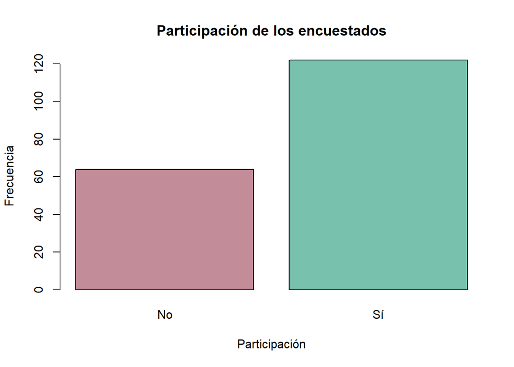

```
## [1] "Si participan: 122 / 65.59 %"
```

```
## [1] "No participan: 64 / 34.41 %"
```

65.59% de los encuestados si realizan alguna una actividad extracurricular, mientras que el resto no realiza ninguna. Es importante recordar que cuando se este comparando los datos entre actividades se trabajará únicamente sobre 65.59% de los encuestados.

**Edad:**

Para describir de la manera más adecuada la edad se utilizará en primer lugar la desviación estándar y un boxplot.

```
## [1] "Desviación estándar: 1.75"
```

La desviación estándar nos indica que en promedio los valores de edad varían menos de 2 años a la media de estos. Por lo tanto sabemos que los datos de esta variable van a estar mayormente agrupados cerca de la media.

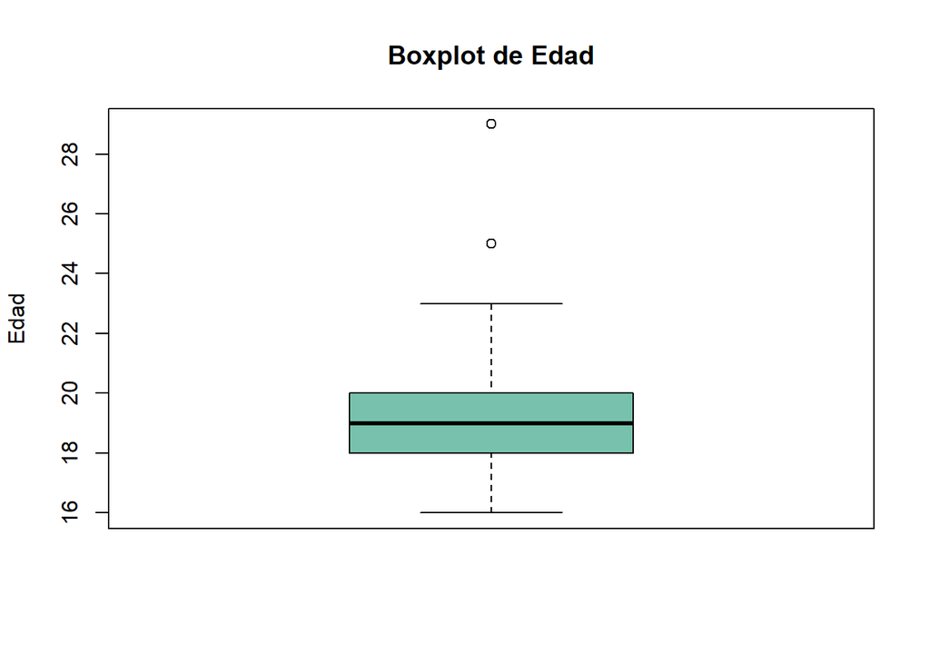

```
## [1] "Datos átipicos: 2"
```

```
## [1] "Dato máximo: 29"
```

En el gráfico se puede observar que la división hecha por la media dentro del 50% medio de los datos los separa similarmente, por lo que tanto la mediana sería un descriptor adecuado.

Sin embargo se puede comprobar que hay dos datos atípicos que se encuentran por arriba de la gran parte de datos. El máximo de los valores es 29, lo cual es una edad realista entre estudiantes universitarios y debería ser utilizada. Por esta razón la media de igual manera es un buen descriptor

```
## [1] "Media: 19.3"
```

```
## [1] "Mediana: 19"
```

Sabemos que en promedio la edad entre los encuestados es de 19.3

**Relación entre Género y participación:**

Para saber que tanto puede influir el género en las respuestas es necesario saber la proporción de personas que participan y no participan en actividades extracurriculares. Para esto se van a graficar los datos en un gráfico de mosaico y se analizaran las proporciones.

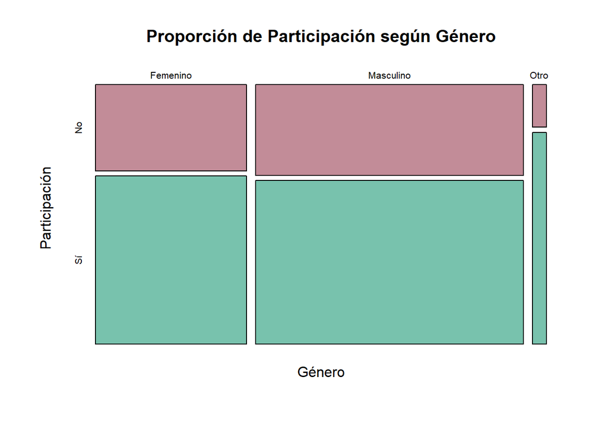

Distribución entre quienes participan:

```
## [1] "Femenino: 43 / 35.25 %"
```

```
## [1] "Masculino: 74 / 60.66 %"
```

```
## [1] "Otro: 5 / 4.1 %"
```

Distribución entre quienes no participan:

```
## [1] "Femenino: 22 / 34.38 %"
```

```
## [1] "Masculino: 41 / 64.06 %"
```

```
## [1] "Otro: 1 / 1.56 %"
```

Como se puede observar tanto en las gráficas como en los porcentajes, la proporcion de genero entre quienes participan en actividades y quienes no participan únicamente varía entre 0.87% y 3.4%, por lo que podemos asumir que el género no es un factor que afectará de gran manera los resultados.

**Carreras:**

En todo el alumnado de la UTEC la proporción de estudiantes de cada carrera no es la misma, ya que depende de la popularidad de la carrera. Sabiendo esto los resultados obtenidos deberían seguir este comportamiento, para comprobarlo se graficarán y analizarán estos datos.

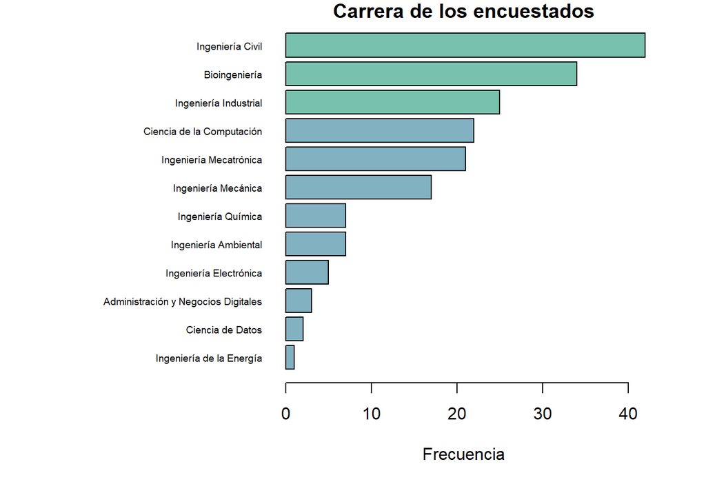

Como se puede observar la moda de la variable carrera entre los encuestados es Ingeniería Civil, luego le sigue Bioingeniería y en tercer lugar Ingeniería Industrial.

```
## [1] "Ingeniería Civil : 42 / 22.58 %"
```

```
## [1] "Bioingeniería : 34 / 18.28 %"
```

```
## [1] "Ingeniería Industrial : 25 / 13.44 %"
```

```
## [1] "Suma: 54.3 %"
```

El conjunto de estas tres carreras representan poco más de la mitad de la muestra, mientras que el porcentaje restante se divide entre el resto de carreras.

**Ciclo:**

Para analizar de mejor manera los datos es importante saber de que ciclos es la mayor parte de la información.

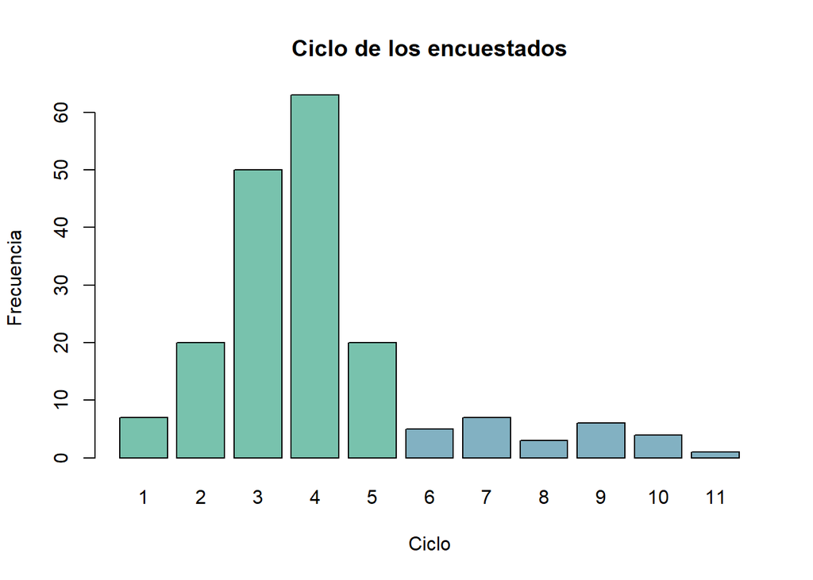

El ciclo más común entre los encuestados es el cuarto ciclo, lo que lo hace la moda. Otro ciclo que es frecuente como respuesta es el tercero.

```
## [1] "Cuarto ciclo: 63 / 33.87 %"
```

```
## [1] "Tercer ciclo: 50 / 26.88 %"
```

```
## [1] "Suma: 60.75 %"
```

Considerando que los ciclos están ordenados de manera ascendente, se puede observar que los encuestados tienden a indicar que son de ciclos menores (Entre el 1 al 5).

```
## [1] "Suma: 86.02 %"
```

Se puede observar que el 86% de la muestra se encuentra entre estos ciclos. Es necesario tener esto en cuenta, ya que las conclusiones de este estudio pueden variar si se analiza únicamente a estudiantes de ciclos superiores.

**Cantidad de actividades:**

Además de saber si alguien realiza o no realiza alguna actividad extracurricular se debe saber de igual manera la cantidad de actividades que se realizan. Por esta razón analizaremos los datos de quienes si participan en actividades. Al ser una varaible cuantitativa es posible utilizar descriptores numéricos y gráficos.

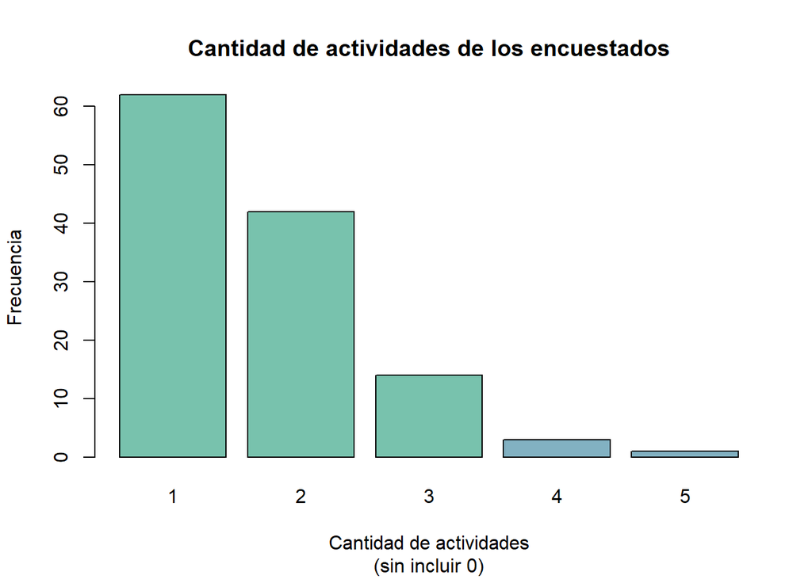

```
## [1] "Promedio: 1.68"
```

```
## [1] "Mediana: 1"
```

```
## [1] "Moda: 1"
```

```
## [1] "Desviación estandar: 0.84"
```

Considerando que la media es mayor a la mediana y a la moda se sabe que los datos y su gráfica tienen una asimetría positiva

Tanto la mediana y la moda tienen el mismo valor, pero en el caso de la media se puede observar que está siendo afectada por los valores extremos (como el 4 o el 5). Esto se puede comprobar con la desviación estándar, la cual es cercana a 1. Además de esto, se puede observar en la gráfica que la cantidad de observaciones que realizan 4 o 5 es muy baja, por lo que los resultados son menos robustos. Debido a esto, al momento de analizar posteriormente la cantidad de actividades solo se analizará los valores 1, 2 y ocasionalmente 3.

## 3.2 Objetivo 1

**Actividades extracurriculares más populares**

**Tipo de Actividad**

En primer lugar se va analizar cual es el tipo de actividad más popular entre los estudiantes. Es importante recalcar que el tipo de actividades son generalizaciones de las actividades.

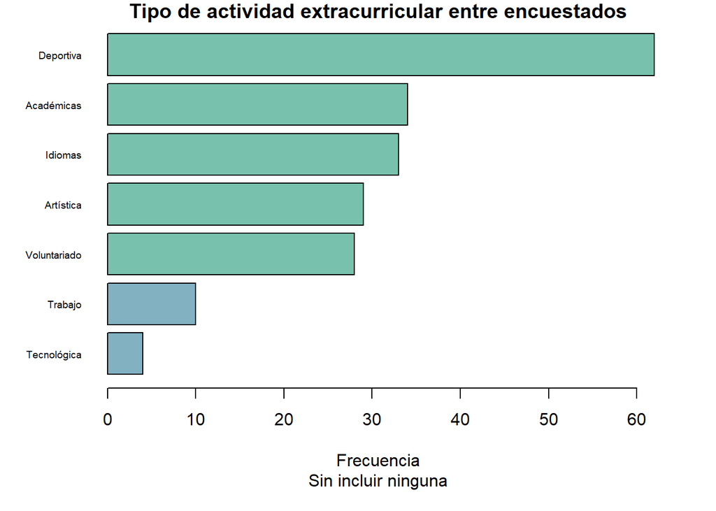

```
## [1] "Moda -> Deportiva: 33.33 % / 50.82 %"
```

Se puede observar que el tipo de actividad extracurricular más popular entre los estudiantes son las actividades deportivas.

Un aproximado de 33% de estudiantes de toda la UTEC realiza alguna actividad deportiva, mientras que entre quienes realizan alguna actividad extracurricular un 50.81% realiza al menos una deportiva.

Las siguientes actividades más comunes son las Académicas, las de idiomas, artísticas y de voluntariado con observaciones cercanas a las 30

**Actividades**

De igual manera se analizan las actividades por separado para saber cuales son las más comunes y de las cuales hay más datos. Para esto se graficarán los datos para analizarlos de manera más sencilla debido a la gran cantidad de respuestas variadas.

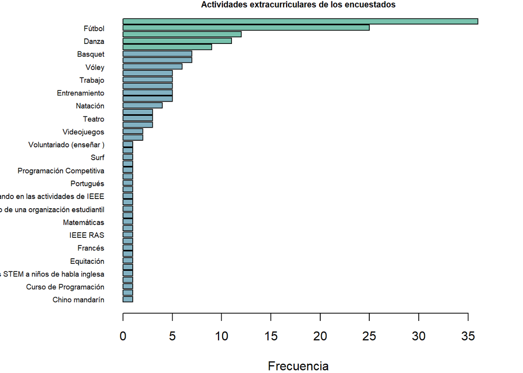

[output not shown]

Como se puede observar, la moda entre las actividades extracurriculares es el inglés. Esto puede parecer contradictorio con la variable anterior (tipo) ya que la moda eran actividades deportivas, pero es importante mencionar que las actividades deportivas se pueden dividir entre varias actividades.

Un ejemplo de esto es el fútbol, que va justo detrás de inglés, la danza también se puede conciderar deportiva, el basquet, voley, entrenamiento, entre otros.

Debido a la poca cantidad de datos en muchos de los valores, se analizarán únicamente las 5 actividades com mayor cantidad de observaciones.

### 3.2.1 Conclusión

El tipo de actividad extracurricular más popular entre los estudiantes de UTEC del ciclo 2023-1 son las actividades deportivas, pero la actividad particular más popular entre los estudiantes de UTEC del ciclo 2023-1 es el inglés.

## 3.3 Objetivo 2

**Relación entre la participación en actividades extracurriculares y el rendimiento académico**

**Distribución de orden de mérito por participación**

El primer aspecto que se comprobará para este objetivo es la relación entre la variable Orden de mérito y Participación, debido a que ambas son cualitativas se representarán en un gráfico de mosaico.

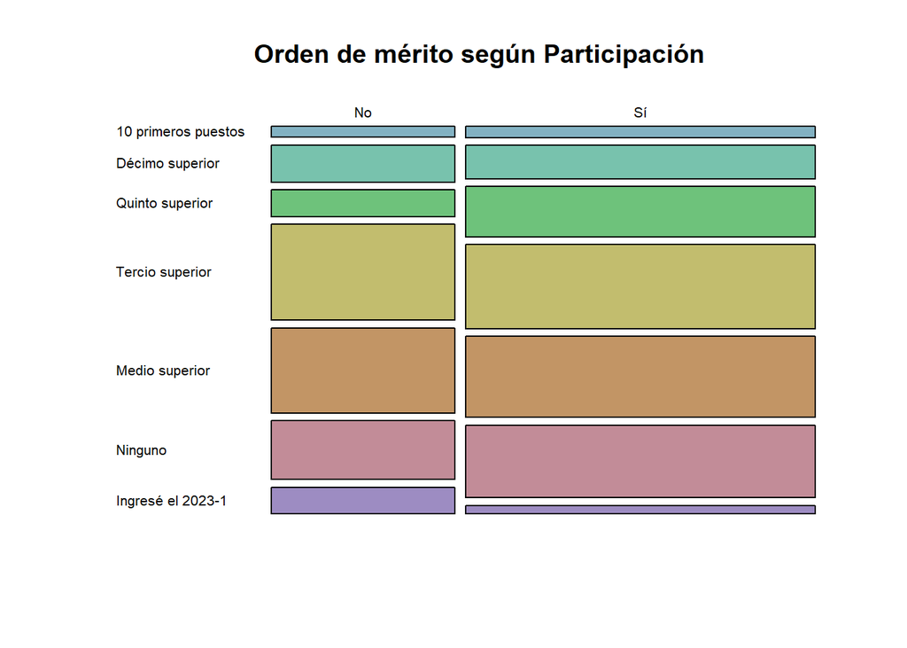

Gráficamente se puede observar que la distribución de orden superior no varía mucho respecto a si alguien participa en alguna actividad extracurricular o no. Debido a esto la relación entre el orden de mérito y la participación en actividades extracurriculares indican que no existe una relación.

**Hora de dedicadas a clases vs horas dedicadas a actividades a la semana**

Otro aspecto a comparar es si la cantidad de horas que se dedican a las actividades afecta a la cantiad de horas que se dedican a clases. Para esto se compararán las variables Horas de estudio y Horas Actividades. Ambas son variables cuantitativas que pueden ser comparadas mediante un gráfico de dispersión y su correlación.

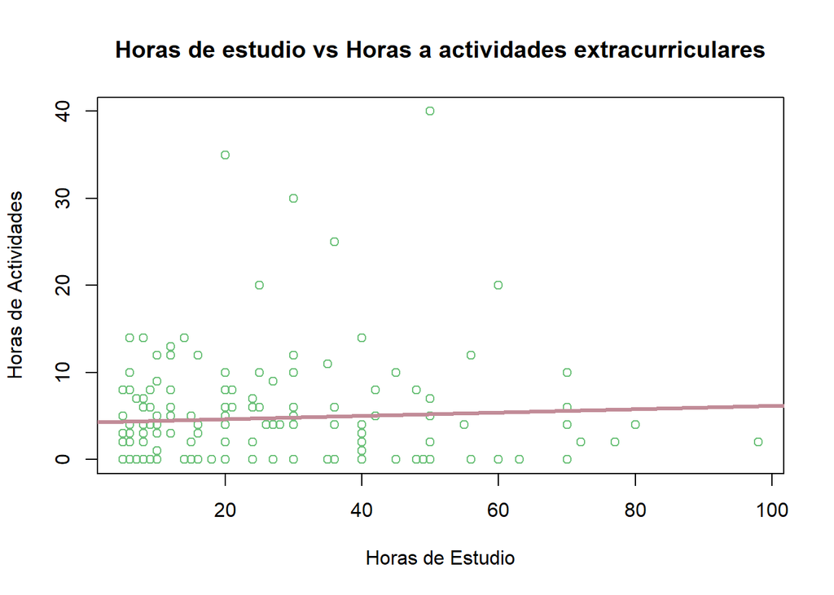

```
## [1] "Correlación: 0.06"
```

Al comparar la cantidad de horas dedicadas a los estudios vs la cantidad de horas dedicadas a las actividades se puede observar que dedicar más horas a las actividades no necesariamente significa dedicar menos horas a los estudios. En sí las variables no tienen una gran relación, lo que se puede comprobar en la correlación. En analisis de estas varaibles indican que no existe relación.

**Relación de Cantidad de actividades y Horas de estudio**

Se comparan de igual manera la cantidad de actividades que se realizan vs las horas de estudio, debido a que ambas son variables cuantitativas pero solo se analizarán tres valores de cantidades de actividades se graficará un boxplot.

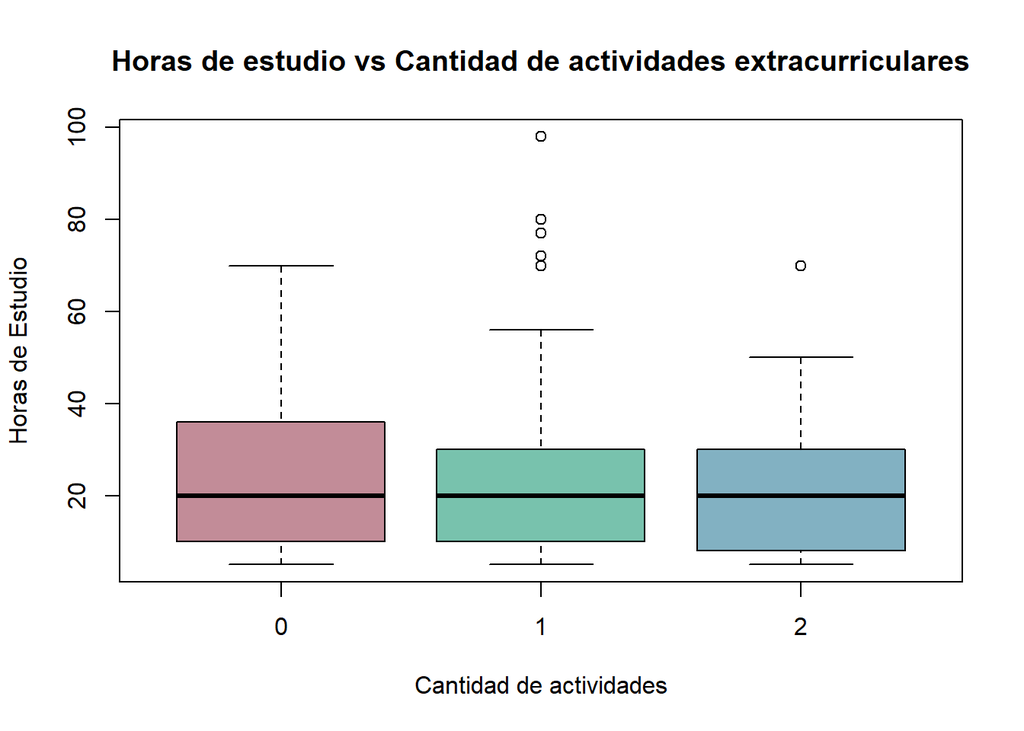

```
## [1] "Mediana de 0 actividad/es: 20"
```

```
## [1] "Mediana de 1 actividad/es: 20"
```

```
## [1] "Mediana de 2 actividad/es: 20"
```

Si analizamos los datos dejando de lado los datos atipicos nos podemos percatar de que la mediana en las tres cantidades es la misma (20 horas). Lo que cambia si cambia es que la proporción del 50% medio de los datos pasa de estar concentrada en el cuarto superior (más horas de estudio) en 0 actividades al cuarto inferior (menos horas de estudio) en 2 actividades. Además de esto el rango máximo de datos no atipicos también disminuye mientras la cantidad aumenta.

Se puede afirmar que la relación que existe entre estas variables no es evidente, pero existe y es negativa. Esto significa que según la relación de estas varaibles si existe relación y esta afecta negativamente.

**Relación entre la participación en actividades extracurriculares y reprobar un curso**

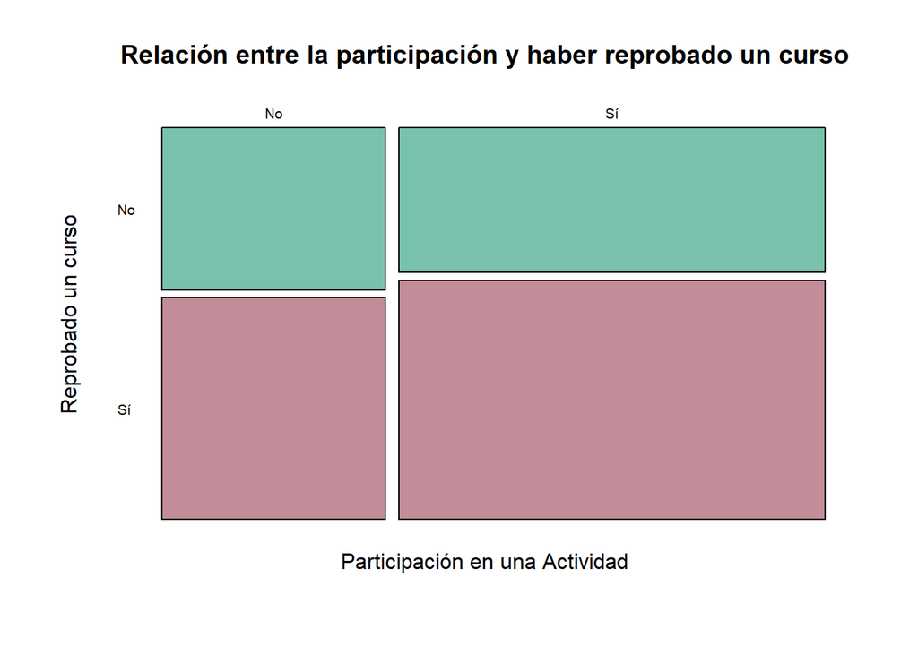

Participan en una actividad:

```
## [1] "No Reprobado: 37.7 %"
```

```
## [1] "Reprobado: 62.3 %"
```

No participan en una actividad:

```
## [1] "No Reprobado: 42.19 %"
```

```
## [1] "Reprobado: 57.81 %"
```

En ambos casos el porcentaje de reprobados es mayor, pero la diferencia entre los porcentajes es de un 4.5% teniendo mayor proporción de reprobados quienes participan en alguna actividad extracurricular. Aunque la diferencia no sea mucha se puede afirmar que si la participación afecta en cuanto a reprobar un curso esta lo haría, haciendolo más probable.

### 3.3.1 Conclusión 1

La participación en actividades extracurriculares se relaciona ligeramente de manera negativa con el rendimiento académico de los estudiantes de la UTEC en el ciclo 2023-1.

**Relación entre tipo de actividad y rendimiento académico:**

Para obtener más resultados se analizará también la relación de los diferentes tipos de actividades con el rendimiento académico. Para esto se tomará el porcentaje de reprobados de cada tipo de actividad y el promedio de horas de estudio.

```
##           Tipo Reprobados Horas.de.estudio
## 1    Deportiva      64.52            20.32
## 2      Idiomas      69.70            22.33
## 3   Académicas      52.94            26.88
## 4    Artística      65.52            26.48
## 5 Voluntariado      75.00            20.18
```

Si consideramos únicamente el porcentaje de reprobados, aquellos tienen un mejor desempeño son quienes realizan una actividad extracurricula académicas (53%) mientras que aquellos con un peor desempeño son quienes participan en voluntariado (75%)

Si consideramos únicamente las horas de estudio, aquellos dedican más horas semanales a sus estudios son quienes participan en actividades extracurriculares académicas (27), mientras quienes dedican menos tiempo a sus estudios son lo que participan actividades de voluntariado (20.2)

**Relación entre actividad y rendimiento académico:**

De igual manera se analizará la relación de los las 5 actividades más populares con el rendimiento académico. Para esto se tomará el porcentaje de reprobados de cada tipo de actividad y el promedio de horas de estudio.

```
##   Actividades Reprobados Horas.de.estudio
## 1      Inglés      52.78            21.36
## 2      Fútbol      68.00            22.76
## 3      Música      75.00            31.17
## 4       Danza      54.55            33.91
## 5      Dibujo      77.78            26.22
```

### 3.3.2 Conclusión 2

Según los resultados, los estudiantes de la UTEC durante el ciclo 2023-1 que realizan actividades extracurriculares académicas tienen el mejor desempeños académico, mientras que aquellos que realizan actividades de voluntariados son quienes tienen el peor desempeño académico.

En cuanto a las actividades especificas la información obtenida no demuestra relación.

## 3.4 Objetivo 3

**Relación de las actividades extracurriculares con el desarrollo de habilidades blandas**

**Relación entre participación y autopercepción de habilidades sociales**

Para analizar la relación con las habilidades blandas se empezará a analizar la relación entre las varaibles Participación y Nivel Habilidades, debido a que ambas son cualitativas se graficarán.

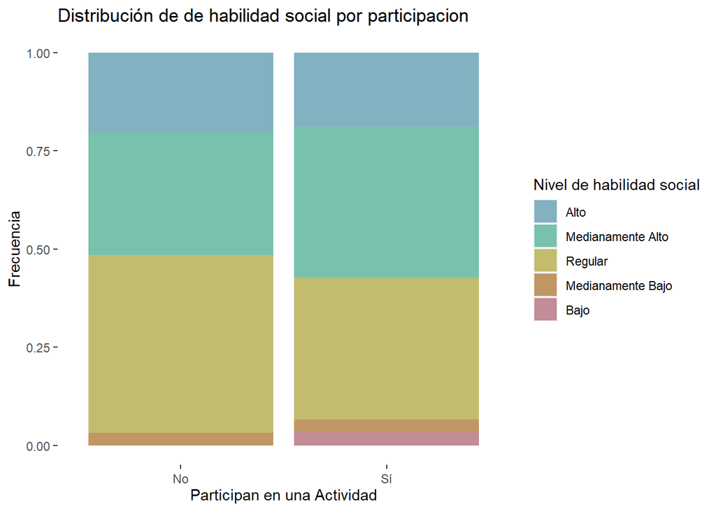

Entre el gráfico de participación y no participación se puede destacar es que la mayoría de respuestas estan entre “regular” y “Medianamente Alto”. La proporcion entre quienes participan en actividades tiende a “medinamente alto”, mientras en quienes no participan predomina la opinion “regular”. Esto indica que que aquellos que participan en actividades extracurriculares suelen tener una autopercepción de sus habilidades sociales más positiva.

**Relación de entre cantidad y amistades/contactos hechos en actividades**

Para analizar si las actividades extracurriculares afectan al circulo social de un estudiante se analizará las variables Amistades y Cantidad. Ambas son variables cuantitavas y se realizará un boxplot.

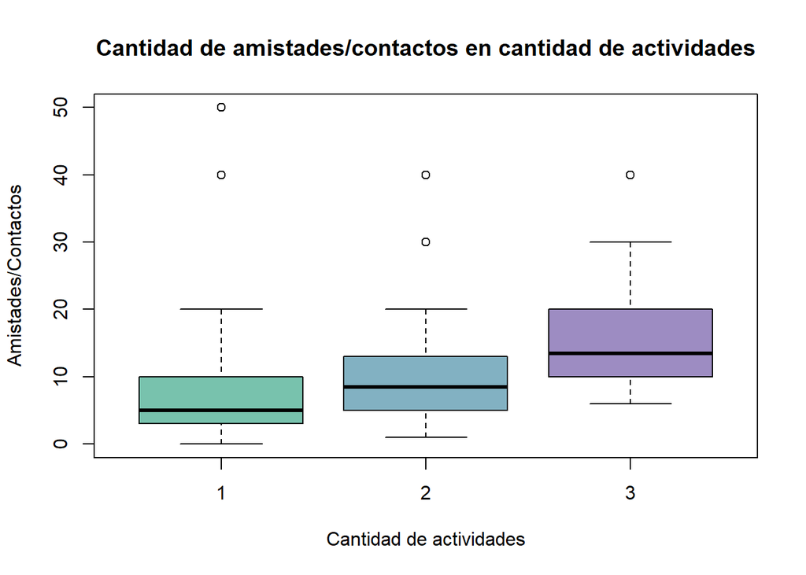

Ignorando los datos atipicos se puede observar que el conjunto de datos de la cantidad de amistastes en actividades extracurriculares aumenta a medida que la cantidad de actividades aumenta. Esto demuestra que ambas varaibles están relacionadas y por lo tanto las actividades extracurriculares si tienen alguna relación con las habilidades blandas de los estudiantes.

**Puntaje de test según participación**

En la encuesta los estudiantes realizaron un test para medir sus habilidades sociales y de liderazgo de manera más objetiva. Debido a que el test es una varaible cuantitativa se usarán descriptores numéricos y gráficos. Se utilizará la media debido a que los datos se encuentran en un rango especifico dado por el test.

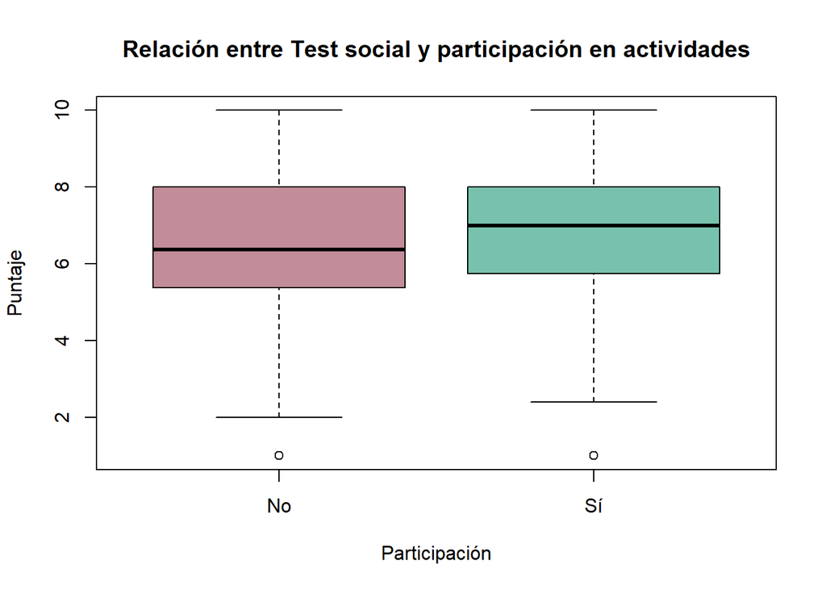

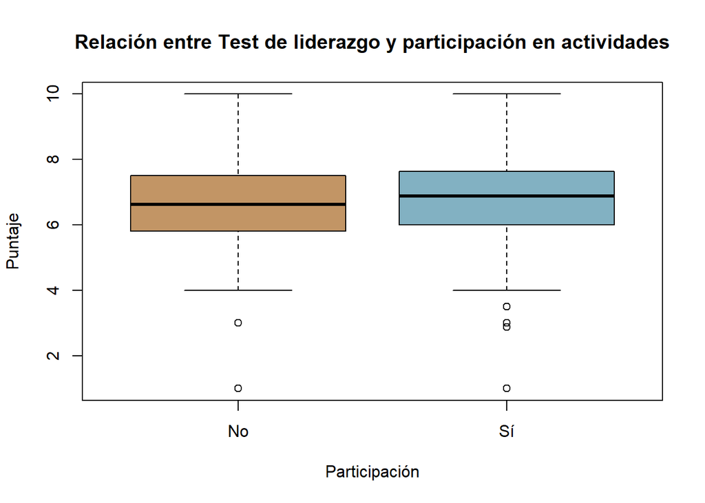

Puntaje entre quienes participan:

```
## [1] "Media del Test Social: 6.66"
```

```
## [1] "Media del Test de Liderazgo: 6.78"
```

Puntaje entre quienes no participan:

```
## [1] "Media del Test Social: 6.36"
```

```
## [1] "Media del Test de Liderazgo: 6.56"
```

### 3.4.1 Conclusión 1

La participación en actividades extracurriculares se relaciona ligeramente de manera positiva con el desarrollo de habilidades blandas de los estudiantes de la UTEC en el ciclo 2023-1.

**Relación entre tipo de actividad y habilidades sociales:**

Debido a la cantidad de datos que hay para cada valor se utilizará la mediana en lugar de la media para describir las amistades, ya que la media en un descriptor poco robusto que es incluso más sensible con poca cantidad de datos.

```
##           Tipo Mediana.Amistades Media.Test.Social Media.Test.de.Liderazgo
## 1    Deportiva               6.5              6.90                    7.00
## 2      Idiomas               7.0              6.23                    6.72
## 3   Académicas              10.0              6.94                    6.76
## 4    Artística               6.0              6.66                    6.92
## 5 Voluntariado              14.0              6.52                    6.97
```

Aquellos que realizan una actividad de voluntariado como actividad extracurricular suelen hace más amistades en las actividades (14) mientras que los que menos hacen son quienes realizan actividades artísticas (6).

Quienes tienen habilidades sociales más desarrolladas son quienes participan en actividades extracurriculares académicas (6.94) y aquellos con menor desarrollo son participantes de actividades de idiomas (6.23).

Quienes tienen habilidades de liderazgo mejor desarrolladas son aquellos que participan en actividades extracurriculares deportivas (7) y aquellos que las tienen menos desarrolladas son los de idiomas (6.72).

De igual manera se utilizarán descriptores gráficos y númericos, utlizando la mediana en lugar de la media para describir las amistades, ya que la media en un descriptor poco robusto que es incluso más sensible con poca cantidad de datos.

```
##   Actividad Mediana.Amistades Media.Test.Social Media.Test.de.Liderazgo
## 1    Inglés                 8              6.26                    6.70
## 2    Fútbol                10              6.52                    7.13
## 3    Música                10              7.19                    7.01
## 4     Danza                10              6.32                    6.71
## 5    Dibujo                 5              6.83                    7.08
```

Aquellos que realizan fútbol, música o danza suelen hace más amistades en las actividades (10) mientras que los que menos hacen son quienes realizan dibujo (5).

Quienes tienen habilidades sociales más desarrolladas son quienes participan en música (7.19) y aquellos con menor desarrollo son quiene estudian inglés (6.26).

### 3.4.2 Conclusión 2

Según los resultados, los estudiantes de la UTEC durante el ciclo 2023-1 que realizan actividades extracurriculares académicas tienen más desarrolladas las habilidades blandas, mientras que aquellos que realizan actividades de idiomas son quienes tienen un peor desarrollo de habilidades blandas.